# A/B Testing in Political Communications

Sumer Gupta

University of Essex

2026-02-19

```r
library(ggplot2)
```

## Introduction

This project simulates a randomized controlled trial (RCT) to determine which type of digital messaging, such as a website homepage with broad policy platforms or one with an issue-focused platform, can be most effective in engaging with supporters. By randomly assigning website visitors to different versions of a homepage, the experiment isolates the causal effect of specific strategies on supporter sign-ups.

### Theoretical Framework

Every visitor has **two potential outcomes**, only one of which we observe:

1. `Y0`: potential of visitor signing up after being shown the standard (control) homepage
2. `Y1`: potential of a visitor signing up after being shown the issue-focused (treatment) homepage.

According to the **fundamental problem of causal inference**, we can never observe both `Y0` and `Y1` for same person, if we show them the treatment homepage, we would never know what would’ve happened under the control homepage, and vice-versa.

Through a RCT, we can estimate the **Average Treatment Effect (ATE)**:

$$\text{ATE} = E[Y_1 - Y_0] = E[Y_1] -
E[Y_0]$$

Because of the average treatment effect, the treatment and control groups are statistically equivalent. The difference in outcomes can then be attributed to treatment, so `E[Y1]` can be estimated from the treatment group and `E[Y0]` from the control group.

## 1. Simulating the Experiment

Experiment setup:

- **Sample size:** 1,500 website visitors
- **Assignment**: Random (There’s a 50% probability a visitor will get either homepage)
- **Control condition**: Standard homepage with broad policy platforms
- **Treatment condition**: Issue-focused homepage
- **Outcome variable**: Supporter sign-up (binary indicator; 1 = yes, 0 = no)
- **Control sign-up rate**: 12% (expected)
- **Treatment sign-up rate**: 17% (expected)

There’s a reason to why this experiment is simulated, real A/B tests would require actual website traffic, ethics approval, informed consent considerations and longer observation periods. A simulation allows us to control the true treatment effect, demonstrate statistical concepts more clearly, explore the heterogeneity systematically and avoid the practical difficulties of a real A/B test.

```r
set.seed(123) # This ensures replicabiltiy
n <- 1500 # Total visitors to the site

# Random treatment assessment
treatment <- rbinom(n = n, size = 1, prob = 0.5)
# rbinom() generates random deviates from a binomial distribution, this is what allows us to simulate our A/B test.

# Potential outcomes for each visitor
p_control <- 0.12 # 12% control sign-up rate
p_treated <- 0.17 # 17% treatment sign-up rate

Y0 <- rbinom(n = n, size = 1, prob = p_control)
Y1 <- rbinom(n = n, size = 1, prob = p_treated)

# Realized outcome - single results actually observed for each visitor,
support_signup <- ifelse(treatment == 1, Y1, Y0)

# Create a data frame
party_ab <- data.frame(
  visitor_id = 1:n,
  treatment = treatment,
  support_signup = support_signup
)
```

## 2. Calculate the Average Treatment Effect (ATE)

We can model a logistic regression to determine how being in the treatment group affects a visitor’s sign-up probability using `glm()`.

```r
logit_model <- glm(support_signup ~ treatment, data = party_ab, family = binomial(link = "logit"))

summary(logit_model)
```

```
##
## Call:
## glm(formula = support_signup ~ treatment, family = binomial(link = "logit"),
##     data = party_ab)
##
## Coefficients:
##             Estimate Std. Error z value Pr(>|z|)
## (Intercept)  -2.1512     0.1189 -18.097  < 2e-16 ***
## treatment     0.4756     0.1558   3.052  0.00227 **
## ---
## Signif. codes:  0 '***' 0.001 '**' 0.01 '*' 0.05 '.' 0.1 ' ' 1
##
## (Dispersion parameter for binomial family taken to be 1)
##
##     Null deviance: 1163.0  on 1499  degrees of freedom
## Residual deviance: 1153.5  on 1498  degrees of freedom
## AIC: 1157.5
##
## Number of Fisher Scoring iterations: 4
```

```r
p_hat_control <- predict(
  logit_model,
  newdata = data.frame(treatment = 0),
  type = "response"
)

# p_hat_control is the predicted probability of the logistic regression model that a specific visitor will sign-up if shown standard homepage

p_hat_treated <-predict(
  logit_model,
  newdata = data.frame(treatment = 1),
  type = "response"
)

# p_hat_treated is the predicted probability of the logistic regression model that a specific visitor will sign-up if shown the issue-focused homepage.

# Given p_hat_control and p_hat_treated, we can calculate the ATE:

ate_logit <- p_hat_treated - p_hat_control

ate_logit
```

```
##         1
## 0.0534603
```

The logistic regression model shows that the value of the ATE is 0.0535 which is 5.35 percentage points, the difference between the percentage of people that signed up after observing the control and treatment homepages.

## 3. Visualization: Treatment Effect by Age

```r
set.seed(2024)

# Simulate visitor ages using a normal distribution, limit them between 18 and 75 to refect a realistic electorate
party_ab$age <- round(pmin(pmax(rnorm(nrow(party_ab), mean = 40, sd = 12), 18), 75))

# Use a binomial distribution to randomly assign a "high interest" trait to 40% of the visitors
party_ab$high_interest <- rbinom(nrow(party_ab), size = 1, prob = 0.4)

# Verify that the new data was added correctly
head(party_ab[, c("visitor_id", "treatment", "support_signup", "age", "high_interest")])
```

```
##   visitor_id treatment support_signup age high_interest
## 1          1         0              1  52             1
## 2          2         1              1  46             1
## 3          3         0              0  39             0
## 4          4         1              0  37             1
## 5          5         1              0  54             1
## 6          6         0              0  56             1
```

```r
# To examine age-related heterogeneity, create a new linear model using lm()
lm_het_age <- lm(support_signup ~ treatment  * age, data = party_ab)

lm_het_age
```

```
##
## Call:
## lm(formula = support_signup ~ treatment * age, data = party_ab)
##
## Coefficients:
##   (Intercept)      treatment            age  treatment:age
##      0.061994       0.004307       0.001042       0.001236
```

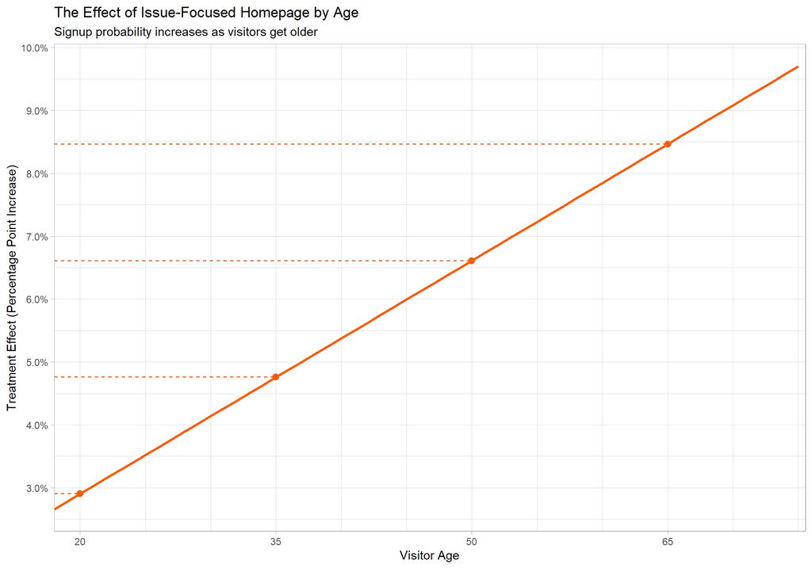

```r
# Create a sequence of ages from 18 to 75.
age_seq <- seq(18,75, by = 1)

# Create a new sequence for displaying larger intervals
major_age <- seq(20,75, by = 15)

# Extract coefficients from lm_het_age
treat <- coef(lm_het_age)["treatment"]
inter <- coef(lm_het_age)["treatment:age"]

# Create a data frame for the plot
marginal_effect_data <- data.frame(
  age = age_seq,
  treatment_effect = treat + (inter * age_seq)
)

# Filter the dataset to include only the rows where the visitor's age matches the 15-year intervals
interval_data <- subset(marginal_effect_data, age %in% major_age)

# Plot the marginal effect of age on treatment
ggplot(marginal_effect_data, aes(x = age, y = treatment_effect)) +
  geom_line(colour = "#F45D0B", linewidth = 1.2) +
  geom_segment(data = interval_data,
               aes(x = 18, xend = age,
                   y = treatment_effect, yend = treatment_effect),
               linetype = "dashed", colour = "#C84C09") +
  geom_point(data = interval_data,
             colour = "#F45D0B",
             size = 2.5) +
  scale_x_continuous(breaks = major_age,
                     minor_breaks = seq(15,75, by = 5),
                     limits = c(18,75),
                     expand = expansion(mult = c(0,0.01))
                     ) +
  scale_y_continuous(labels = scales::percent_format(accuracy = 0.1),
                     breaks = seq (0, 0.1, by = 0.01)) +
  labs(
    title = "The Effect of Issue-Focused Homepage by Age",
    subtitle = "Signup probability increases as visitors get older",
    x = "Visitor Age",
    y = "Treatment Effect (Percentage Point Increase)"
) +
  theme(panel.grid.major = element_line(colour = "#DCDCDC" ),
        panel.grid.minor = element_line(colour = "#DCDCDC")
) +
  theme_light()
```